# Solutions for Homework I

Uğurcan Bayraktar

11/15/2021

### Question 1

Firstly, we import the tidyverse.

```r
library(tidyverse)
options(dplyr.print_max = 1e9)
options(scipen = 100)
```

Then, the data should be read. It is assigned to **revenue_data.**

```r
revenue_data <- read_csv("data/Revenue_Chart_Full_Data_data.csv")
```

### Question 2

*Year (copy)*, *Format*, *Value (Actual)* columns are renamed below.

```r
revenue_annually = revenue_data %>%
                    select(`Year (copy)`, Format, `Value (Actual)`) %>%
                    rename(Year = `Year (copy)`,
                           Format = Format,
                           Value = `Value (Actual)`)
```

This is the first 6 rows of the subset.

| Year | Format | Value |
| --- | --- | --- |
| 2005 | Cassette | 13.100000 |
| 2015 | CD Single | 1.196947 |
| 2015 | Paid Subscription | 1156.708514 |
| 2017 | Download Single | 667.875936 |
| 1986 | Vinyl Single | 228.100000 |
| 2003 | DVD Audio | 8.000000 |

Then the year column is sorted.

```r
revenue_annually = revenue_annually %>%
                  filter(Year >= 2018) %>%
                  arrange(Year)
```

| Year | Format | Value |
| --- | --- | --- |
| 2018 | Vinyl Single | 5.7206009 |
| 2018 | SoundExchange Distributions | 952.8000000 |
| 2018 | Ringtones & Ringbacks | 24.9578598 |
| 2018 | SACD | 0.8596997 |
| 2018 | Download Music Video | 2.2208106 |
| 2018 | Paid Subscription | 4614.0185024 |

Finally, annually revenue is calculated from 2018 to 2020.

```r
revenue_annually = revenue_annually %>%
                    group_by(Year) %>%
                    summarise(`Value (Yearly)` = sum(Value))
```

| Year | Value (Yearly) |
| --- | --- |
| 2018 | 9738.197 |
| 2019 | 11130.353 |
| 2020 | 12153.351 |

### Question 3

Created a subset that includes the streaming formats.

```r
streaming_revenue = revenue_data %>%
                      select(Year, Streaming = Format, Value = `Value (Actual)`) %>%
                      filter(Streaming %in% c("Paid Subscription",
                                           "On-Demand Streaming (Ad-Supported)",
                                           "Other Ad-Supported Streaming",
                                           "SoundExchange Distributions",
                                           "Limited Tier Paid Subscription"),
                                            Year == 2020) %>%
                      arrange(Streaming)
```

| Year | Streaming | Value |
| --- | --- | --- |
| 2020 | Limited Tier Paid Subscription | 723.6147 |
| 2020 | On-Demand Streaming (Ad-Supported) | 1183.1214 |
| 2020 | Other Ad-Supported Streaming | 211.2476 |
| 2020 | Paid Subscription | 7009.1655 |
| 2020 | SoundExchange Distributions | 947.4000 |

The total streaming music revenue is approximately $10.1 billion in 2020.

```r
streaming_revenue = streaming_revenue %>%
                      group_by(Year)%>%
                      summarise(`Streaming Revenue` = sum(Value))
```

| Year | Streaming Revenue |
| --- | --- |
| 2020 | 10074.55 |

### Question 4

To begin with, I created a subset named as **revenue_share**, then made a new column which is named as **Categories** consists of *Streaming*, *Synchronization*, *Physical*, *Digital Downloads* and *Other* categories.

```r
revenue_share = revenue_data %>%
                  select(Year, Format, Value= `Value (Actual)`) %>%
                  filter(Year == 2020) %>%
                  mutate(Category = case_when(
                    Format %in% c("Paid Subscription",
                                  "On-Demand Streaming (Ad-Supported)",
                                  "Other Ad-Supported Streaming",
                                  "SoundExchange Distributions",
                                  "Limited Tier Paid Subscription") ~ "Streaming",
                    Format %in% c("Synchronization") ~ "Synchronization",
                    Format %in% c("LP/EP", "CD") ~ "Physical",
                    Format %in% c("Download Album",
                                  "Download Single") ~ "Digital Downloads",
                    TRUE ~ "Other"))
```

Finally, I created a new column includes a revenue shares as percentages and sorted in decreasing order.

```r
revenue_share = revenue_share %>%
                  group_by(Category) %>%
                  summarise(Revenue_Total = sum(Value)) %>%
                  mutate(Share = round(Revenue_Total / sum(Revenue_Total),2)) %>%
                  arrange(-Share)
```

| Category | Revenue_Total | Share |
| --- | --- | --- |
| Streaming | 10074.5491 | 0.83 |
| Physical | 1102.9506 | 0.09 |
| Digital Downloads | 632.3201 | 0.05 |
| Synchronization | 265.2361 | 0.02 |
| Other | 78.2956 | 0.01 |

### Question 5

Radio revenue data is created below. It includes *SoundExchange Distributions* and *Other Ad-Supported Streaming* revenues from 2018 to 2020.

```r
radio_revenue <- revenue_data %>%
                    select(Year, Format, Value = `Value (For Charting)`) %>%
                    filter(Year >= 2018,
                           Format %in% c("SoundExchange Distributions",
                                         "Other Ad-Supported Streaming")) %>%
                    arrange(Year)
```

Here is another subset created for charting the **annually revenues** in the **radio revenue** data.

```r
radrev_annually <- radio_revenue %>%
                    group_by(Year) %>%
                    summarise(Value_Annually = sum(Value))
```

Graph is created below.

```r
#Creating graph with ggplot
#Filled the stack bars in order with levels
g <- ggplot(radio_revenue, aes(x = Year,
                               y = Value,
                               fill = factor(Format,
                                             levels = c("Other Ad-Supported Streaming",
                                                        "SoundExchange Distributions")))) +
       geom_bar(stat = "identity") + #Bar graph will be used

       #Labels are created as same as the original figure.
       labs(x = "", y = "$ MILLIONS",
            title = "U.S. DIGITAL AND CUSTOMIZED RADIO REVENUES",
            subtitle = "Source: RIAA")+

       #Theme is updated: title, subtitle and legend are adjusted.
       theme(plot.title = element_text(size = 14, face = "bold", hjust = 0.5),
            plot.subtitle = element_text(hjust = 0.5),
            legend.position = c(0.5,0),
            legend.margin = margin(0,0,-23,0),
            legend.box.margin = margin(0,0,-23,0),
            legend.direction = "horizontal",
            legend.text = element_text(size = 11)) +
            #Filling colors: Online hex identifier is used to obtain hex values.
            scale_fill_manual("",
                       values = c("SoundExchange Distributions"  = "#2d7a7a",
                                  "Other Ad-Supported Streaming" = "#c2da74"))
```

Combined our graph with the annual revenues.

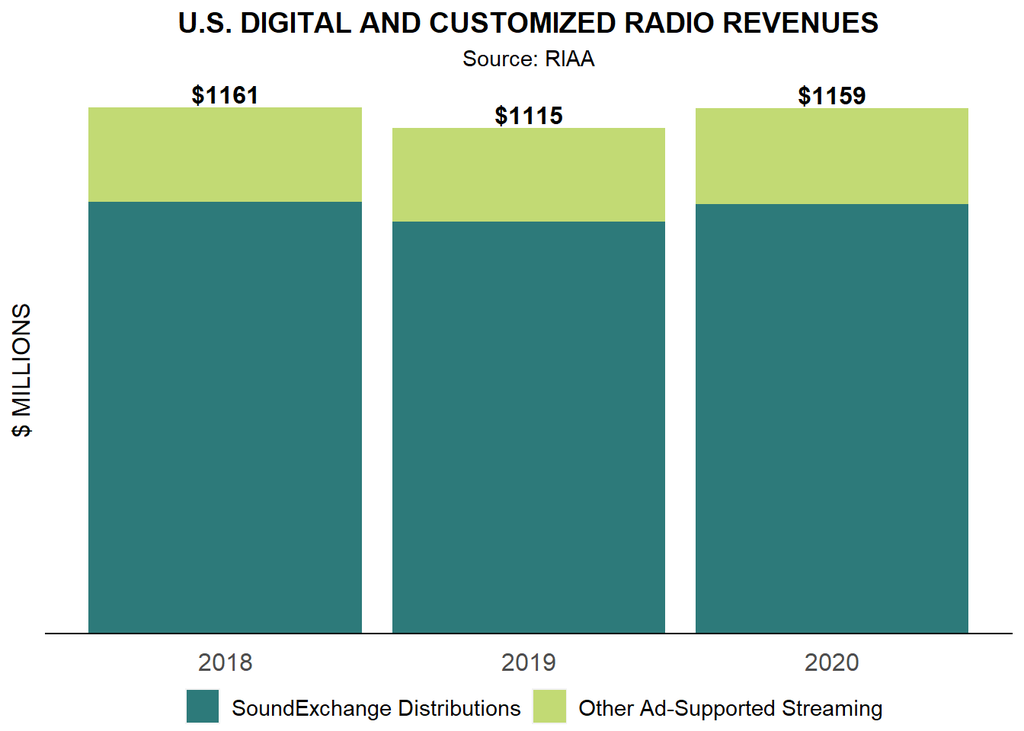

```r
g +
  #Background and axes are removed.
  #Text of x axis and the title of y axis are resized and positioned properly.
  theme(panel.background = element_blank(),
          axis.ticks = element_blank(),
          axis.line = element_blank(),
          axis.text.y  = element_blank(),
          axis.text.x = element_text(vjust = 5, size = 12),
          axis.title.y = element_text(size = 12)) +
  #X axis  was not at the bottom of the stacked bar,
  #Therefore geom_hline() is used to create an x axis same as the original figure.
  geom_hline(yintercept = 0) +

  #Text for the value of annual revenue is created. Adjusted its text, font and position properly.
  geom_text(aes(Year, Value_Annually,
                label = sprintf("$%d", round(Value_Annually)), fontface=2, fill = NULL),
                size = 4.25, vjust = -0.25, data = radrev_annually)
```